# Lab 8

## Loading Necessary Packages and Import of Data

```python
import matplotlib.pyplot as plt
import pandas as pd
import numpy as np
from sklearn.pipeline import Pipeline
from sklearn.preprocessing import StandardScaler, OneHotEncoder, PolynomialFeatures
from sklearn.linear_model import LinearRegression, Ridge, Lasso, ElasticNet, LogisticRegression
from sklearn.discriminant_analysis import LinearDiscriminantAnalysis
from sklearn.svm import SVC
from sklearn.model_selection import train_test_split, cross_val_score, cross_val_predict
from sklearn.metrics import r2_score, confusion_matrix, accuracy_score, precision_recall_fscore_support, roc_auc_score, ConfusionMatrixDisplay, RocCurveDisplay, recall_score, precision_score, make_scorer, cohen_kappa_score
from sklearn.pipeline import Pipeline
from sklearn.compose import make_column_selector, ColumnTransformer
from sklearn.model_selection import GridSearchCV
import matplotlib.pyplot as plt
from palmerpenguins import load_penguins
from sklearn.neighbors import KNeighborsRegressor, KNeighborsClassifier
from sklearn.tree import DecisionTreeRegressor, DecisionTreeClassifier, plot_tree
from sklearn.discriminant_analysis import LinearDiscriminantAnalysis, QuadraticDiscriminantAnalysis
```

```python
cannabis=pd.read_csv("~/Desktop/GSB 544/Labs/Lab 8/cannabis_full.csv", sep=',')
cannabis.head()
```

|  | Strain | Type | Rating | Effects | Flavor | Creative | Energetic | Tingly | Euphoric | Relaxed | ... | Ammonia | Minty | Tree | Fruit | Butter | Pineapple | Tar | Rose | Plum | Pear |
| --- | --- | --- | --- | --- | --- | --- | --- | --- | --- | --- | --- | --- | --- | --- | --- | --- | --- | --- | --- | --- | --- |
| 0 | 100-Og | hybrid | 4.0 | Creative,Energetic,Tingly,Euphoric,Relaxed | Earthy,Sweet,Citrus | 1.0 | 1.0 | 1.0 | 1.0 | 1.0 | ... | 0.0 | 0.0 | 0.0 | 0.0 | 0.0 | 0.0 | 0.0 | 0.0 | 0.0 | 0.0 |
| 1 | 98-White-Widow | hybrid | 4.7 | Relaxed,Aroused,Creative,Happy,Energetic | Flowery,Violet,Diesel | 1.0 | 1.0 | 0.0 | 0.0 | 1.0 | ... | 0.0 | 0.0 | 0.0 | 0.0 | 0.0 | 0.0 | 0.0 | 0.0 | 0.0 | 0.0 |
| 2 | 1024 | sativa | 4.4 | Uplifted,Happy,Relaxed,Energetic,Creative | Spicy/Herbal,Sage,Woody | 1.0 | 1.0 | 0.0 | 0.0 | 1.0 | ... | 0.0 | 0.0 | 0.0 | 0.0 | 0.0 | 0.0 | 0.0 | 0.0 | 0.0 | 0.0 |
| 3 | 13-Dawgs | hybrid | 4.2 | Tingly,Creative,Hungry,Relaxed,Uplifted | Apricot,Citrus,Grapefruit | 1.0 | 0.0 | 1.0 | 0.0 | 1.0 | ... | 0.0 | 0.0 | 0.0 | 0.0 | 0.0 | 0.0 | 0.0 | 0.0 | 0.0 | 0.0 |
| 4 | 24K-Gold | hybrid | 4.6 | Happy,Relaxed,Euphoric,Uplifted,Talkative | Citrus,Earthy,Orange | 0.0 | 0.0 | 0.0 | 1.0 | 1.0 | ... | 0.0 | 0.0 | 0.0 | 0.0 | 0.0 | 0.0 | 0.0 | 0.0 | 0.0 | 0.0 |

5 rows × 69 columns

```python
cannabis=cannabis.dropna()
```

## Part One: Binary Classification

```python
is_indica_or_sativa=(cannabis["Type"]=="indica")|(cannabis["Type"]=="sativa")
cannabis_type=cannabis[is_indica_or_sativa]
```

```python
X=cannabis_type.drop(columns=["Effects", "Flavor", "Type", "Strain"])
y=cannabis_type["Type"]
```

```python
ct_standardize=ColumnTransformer(
    [("standardize", StandardScaler(), make_column_selector(dtype_include=np.number))],
    remainder="passthrough"
).set_output(transform="pandas")
```

### LDA

First, we fit the LDA model on the data:

```python
lda_pipeline=Pipeline(
    [("preprocessing", ct_standardize),
    ("LDA", LinearDiscriminantAnalysis())]
).set_output(transform="pandas")
lda_pipeline.fit(X,y)
```

```
Pipeline(steps=[('preprocessing',
                 ColumnTransformer(remainder='passthrough',
                                   transformers=[('standardize',
                                                  StandardScaler(),
                                                  <sklearn.compose._column_transformer.make_column_selector object at 0x14bbdf230>)])),
                ('LDA', LinearDiscriminantAnalysis())])
```

Now, we can tune the model with the chosen metric: I chose the accuracy metric, as it is a metric that does not give more “power” to a certain type of prediction/category.

```python
lda_value = {'LDA__solver': ("svd", "lsqr", "eigen")}

gscvlda = GridSearchCV(lda_pipeline, lda_value, cv = 5, scoring='accuracy')
gscvlda_fitted = gscvlda.fit(X, y)
print(gscvlda_fitted.best_score_, gscvlda_fitted.best_params_)
```

```
0.8595410469044799 {'LDA__solver': 'svd'}
```

Best model is the default solver SVD. This had a cross validated accuracy score of 0.85954.

```python
scores_lda = cross_val_score(lda_pipeline, X, y, cv=5, scoring='accuracy')
print(scores_lda.mean())
```

```
0.8595410469044799
```

The confusion metric is below:

```
[[597  62]
 [ 88 321]]
```

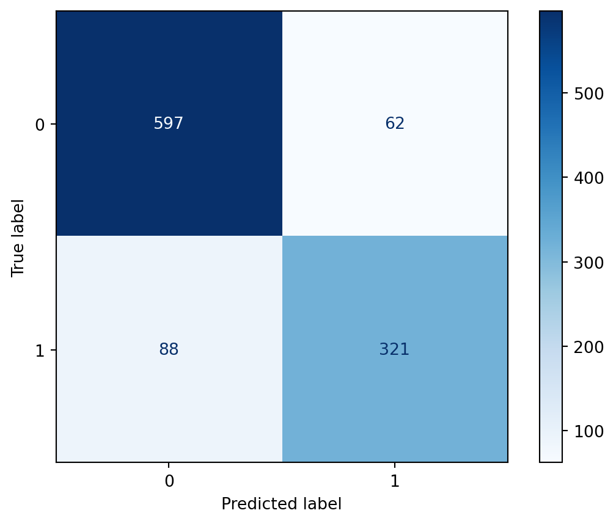

```python
y_pred_lda = cross_val_predict(lda_pipeline, X, y, cv=5)
cm = confusion_matrix(y, y_pred_lda)
disp = ConfusionMatrixDisplay(confusion_matrix=cm)
disp.plot(cmap="Blues")
print(cm)
```

### QDA

```python
qda_pipeline=Pipeline(
    [("preprocessing", ct_standardize),
    ("QDA", QuadraticDiscriminantAnalysis())]
)
qda_pipeline.fit(X,y)
```

```
Pipeline(steps=[('preprocessing',
                 ColumnTransformer(remainder='passthrough',
                                   transformers=[('standardize',
                                                  StandardScaler(),
                                                  <sklearn.compose._column_transformer.make_column_selector object at 0x14bbdf230>)])),
                ('QDA', QuadraticDiscriminantAnalysis())])
```

```python
qda_value = {'QDA__reg_param': (0.001, 0.01, 0.1, 0.5, 0.75, 0.9, 0.99)}

gscvqda = GridSearchCV(qda_pipeline, qda_value, cv = 5, scoring='accuracy')
gscvqda_fitted = gscvqda.fit(X, y)
print(gscvqda_fitted.best_score_, gscvqda_fitted.best_params_)
```

```
0.8577113772980562 {'QDA__reg_param': 0.99}
```

I chose the accuracy metric, as it is a metric that does not give more “power” to a certain type of prediction/category.

We get the highest accuracy prediction tuned to value reg_param = 0.99. Here, we get a cross validated accuacy score of 0.8577.

Now, we will fit this best model on the full dataset.

```python
qda_pipeline_best=Pipeline(
    [("preprocessing", ct_standardize),
    ("QDA", QuadraticDiscriminantAnalysis(reg_param=0.99))]
)
qda_pipeline_best.fit(X,y)
```

```
Pipeline(steps=[('preprocessing',
                 ColumnTransformer(remainder='passthrough',
                                   transformers=[('standardize',
                                                  StandardScaler(),
                                                  <sklearn.compose._column_transformer.make_column_selector object at 0x14bbdf230>)])),
                ('QDA', QuadraticDiscriminantAnalysis(reg_param=0.99))])
```

```
[[587  72]
 [ 80 329]]
```

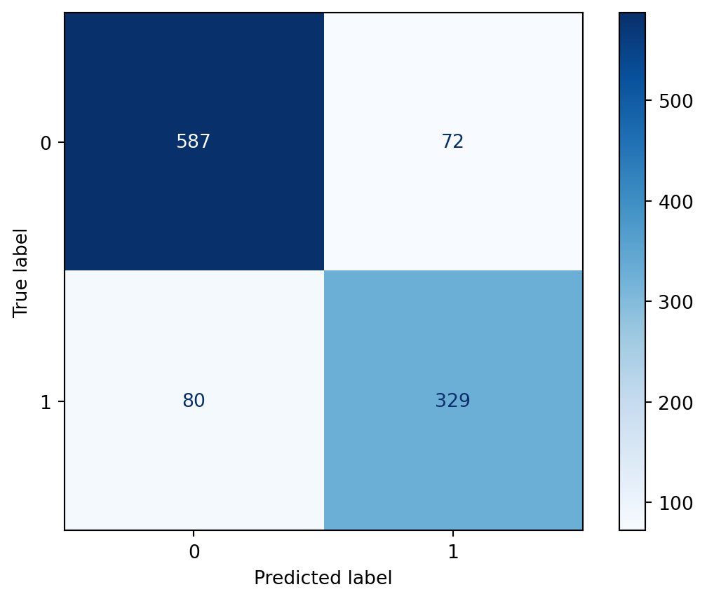

```python
y_pred_qda = cross_val_predict(qda_pipeline_best, X, y, cv=5)
cm = confusion_matrix(y, y_pred_qda)
disp = ConfusionMatrixDisplay(confusion_matrix=cm)
disp.plot(cmap="Blues")
print(cm)
```

### SVC

```python
svc_pipeline=Pipeline(
    [("preprocessing", ct_standardize),
    ("SVC", SVC(kernel="linear"))]
)
svc_pipeline.fit(X,y)
```

```
Pipeline(steps=[('preprocessing',
                 ColumnTransformer(remainder='passthrough',
                                   transformers=[('standardize',
                                                  StandardScaler(),
                                                  <sklearn.compose._column_transformer.make_column_selector object at 0x14bbdf230>)])),
                ('SVC', SVC(kernel='linear'))])
```

```python
c_values = {'SVC__C': [0.001, 0.01, 0.1, 1, 10, 100]}

gscv_svc = GridSearchCV(svc_pipeline, c_values, cv = 5, scoring='accuracy')
gscv_svc_fitted = gscv_svc.fit(X, y)
print(gscv_svc_fitted.best_score_, gscv_svc_fitted.best_params_)
```

```
0.8586196305559213 {'SVC__C': 0.1}
```

Optimal SVC C value is 0.1, for this hyperparameter we recieve a cross validated accuracy score of 0.8586.

```python
svc_pipeline_best=Pipeline(
    [("preprocessing", ct_standardize),
    ("SVC", SVC(C=0.1, kernel='linear'))]
)
svc_pipeline_best.fit(X,y)
```

```
Pipeline(steps=[('preprocessing',
                 ColumnTransformer(remainder='passthrough',
                                   transformers=[('standardize',
                                                  StandardScaler(),
                                                  <sklearn.compose._column_transformer.make_column_selector object at 0x14bbdf230>)])),
                ('SVC', SVC(C=0.1, kernel='linear'))])
```

```
[[591  68]
 [ 83 326]]
```

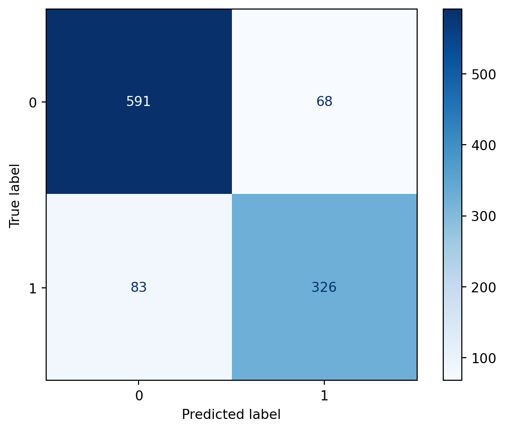

```python
y_pred_svc = cross_val_predict(svc_pipeline_best, X, y, cv=5)
cm = confusion_matrix(y, y_pred_svc)
disp = ConfusionMatrixDisplay(confusion_matrix=cm)
disp.plot(cmap="Blues")
print(cm)
```

### SVM

```python
svm_pipeline=Pipeline(
    [("preprocessing", ct_standardize),
    ("SVM", SVC(kernel='poly'))]
)
svm_pipeline.fit(X,y)
```

```
Pipeline(steps=[('preprocessing',
                 ColumnTransformer(remainder='passthrough',
                                   transformers=[('standardize',
                                                  StandardScaler(),
                                                  <sklearn.compose._column_transformer.make_column_selector object at 0x14bbdf230>)])),
                ('SVM', SVC(kernel='poly'))])
```

```python
c_value = {'SVM__C': [0.001, 0.01, 0.1, 1, 10, 100]}

gscv_svm = GridSearchCV(svm_pipeline, c_value, cv = 5, scoring='accuracy')
gscv_svm_fitted = gscv_svm.fit(X, y)
print(gscv_svm_fitted.best_score_, gscv_svm_fitted.best_params_)
```

```
0.8436839103154755 {'SVM__C': 10}
```

I chose the accuracy metric, as it is a metric that does not give more “power” to a certain type of prediction/category.

We get the highest accuracy prediction tuned to value c value of 10. Here, we get a cross validated accuacy score of 0.84368.

Now, we will fit this best model on the full dataset.

```python
svm_pipeline_best=Pipeline(
    [("preprocessing", ct_standardize),
    ("SVM", SVC(kernel='poly', C=10))]
)
svm_pipeline_best.fit(X,y)
```

```
Pipeline(steps=[('preprocessing',
                 ColumnTransformer(remainder='passthrough',
                                   transformers=[('standardize',
                                                  StandardScaler(),
                                                  <sklearn.compose._column_transformer.make_column_selector object at 0x14bbdf230>)])),
                ('SVM', SVC(C=10, kernel='poly'))])
```

```
[[599  60]
 [107 302]]
```

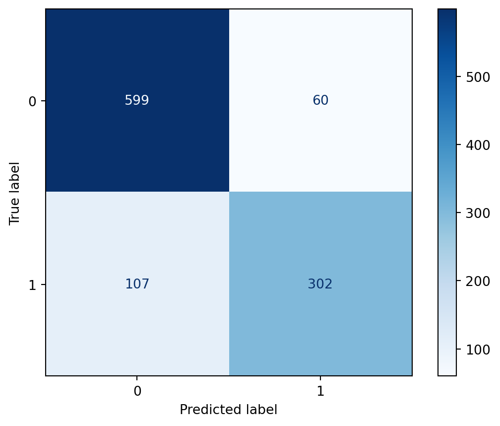

```python
y_pred_svm = cross_val_predict(svm_pipeline_best, X, y, cv=5)
cm = confusion_matrix(y, y_pred_svm)
disp = ConfusionMatrixDisplay(confusion_matrix=cm)
disp.plot(cmap="Blues")
print(cm)
```

## Part 2: Natural Multiclass

```python
X=cannabis.drop(columns=["Effects", "Flavor", "Type", "Strain"])
y=cannabis["Type"]
```

### Decision Tree

```python
tree_pipeline=Pipeline([
    ("preprocessing", ct_standardize),
    ("decision tree", DecisionTreeClassifier())
])

tree_pipeline.fit(X,y)
```

```
Pipeline(steps=[('preprocessing',
                 ColumnTransformer(remainder='passthrough',
                                   transformers=[('standardize',
                                                  StandardScaler(),
                                                  <sklearn.compose._column_transformer.make_column_selector object at 0x14bbdf230>)])),
                ('decision tree', DecisionTreeClassifier())])
```

```python
alphas = {'decision tree__ccp_alpha': (0.0001, 0.001, 0.01, 0.05, 0.075, 0.09, 0.1, 0.11, 1, 10, 50, 100)}
gscvtree= GridSearchCV(tree_pipeline, alphas, cv = 5, scoring='accuracy')
gscvtree_fitted = gscvtree.fit(X, y)
```

```python
print(gscvtree_fitted.best_score_, gscvtree_fitted.best_params_)
```

```
0.6138754537606224 {'decision tree__ccp_alpha': 0.01}
```

We get the highest accuracy prediction tuned to value alpha = 0.01. Here, we get a cross validated accuacy score of 0.613875.

Now, we will fit this best model on the full dataset.

```python
tree_pipeline_best=Pipeline([
    ("preprocessing", ct_standardize),
    ("decision tree", DecisionTreeClassifier(ccp_alpha=0.01))
])

tree_pipeline_best.fit(X,y)
```

```
Pipeline(steps=[('preprocessing',
                 ColumnTransformer(remainder='passthrough',
                                   transformers=[('standardize',
                                                  StandardScaler(),
                                                  <sklearn.compose._column_transformer.make_column_selector object at 0x14bbdf230>)])),
                ('decision tree', DecisionTreeClassifier(ccp_alpha=0.01))])
```

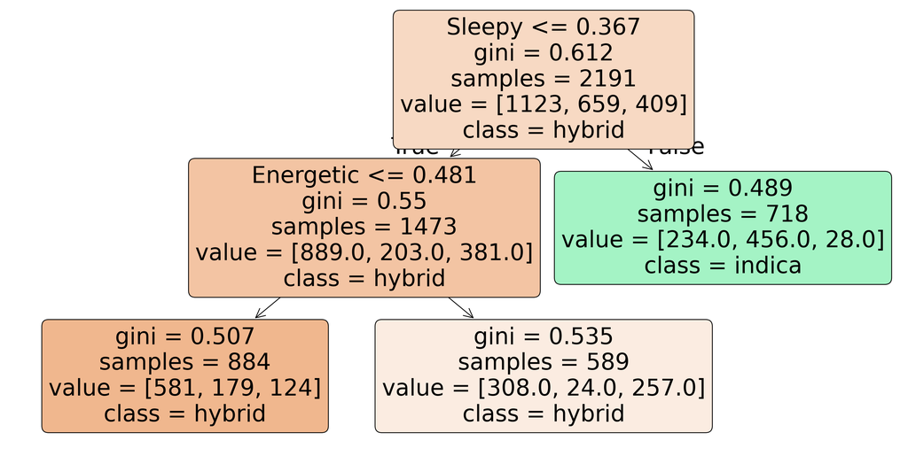

```python
tree = tree_pipeline_best.named_steps["decision tree"]

# Plot it
plt.figure(figsize=(20, 10))
plot_tree(tree,
          feature_names=X.columns,
          class_names=[str(c) for c in tree.classes_],
          filled=True,
          rounded=True)
plt.show()
```

The decision tree results are interesting, as they do not predict any of the strains to be sativa. The decision tree essentially makes one choice between identifying strains as either hybrid or indica and it is the first “choice” the decision tree makes. Then, the tree can additionally split the hybrid strains into two distinct groups. This suggests that indica and hybrid strains are more prominent in the data we have collected, and have more defining characteristics than sativa strains.

### Repeating analysis from part 1 for LDA, QDA, and KNN models

#### 1: LDA

```python
lda_pipeline.fit(X,y)
```

```
Pipeline(steps=[('preprocessing',
                 ColumnTransformer(remainder='passthrough',
                                   transformers=[('standardize',
                                                  StandardScaler(),
                                                  <sklearn.compose._column_transformer.make_column_selector object at 0x14bbdf230>)])),
                ('LDA', LinearDiscriminantAnalysis())])
```

```python
lda_value = {'LDA__solver': ("svd", "lsqr", "eigen")}

gscvlda = GridSearchCV(lda_pipeline, lda_value, cv = 5, scoring='accuracy')
gscvlda_fitted = gscvlda.fit(X, y)
print(gscvlda_fitted.best_score_, gscvlda_fitted.best_params_)
```

```
0.6280244640683995 {'LDA__solver': 'svd'}
```

Using accuracy as a metric as above, we recieve a cross validated score of 0.62802 using the LDA solver SVD. This is the default, so we can proceed with our confusion matrix:

```
[[750 222 151]
 [195 451  13]
 [213  21 175]]
```

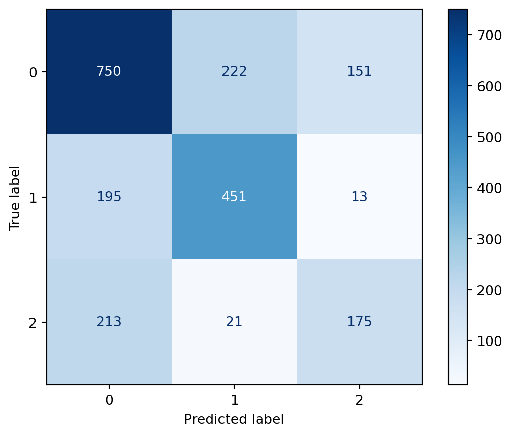

```python
y_pred_lda = cross_val_predict(lda_pipeline, X, y, cv=5)
cm = confusion_matrix(y, y_pred_lda)
disp = ConfusionMatrixDisplay(confusion_matrix=cm)
disp.plot(cmap="Blues")
print(cm)
```

#### 2: QDA

```python
qda_value = {'QDA__reg_param': (0.001, 0.01, 0.1, 0.5, 0.75, 0.9, 0.99)}

gscvqda = GridSearchCV(qda_pipeline, qda_value, cv = 5, scoring='accuracy')
gscvqda_fitted = gscvqda.fit(X, y)
print(gscvqda_fitted.best_score_, gscvqda_fitted.best_params_)
```

```
0.6166224607607577 {'QDA__reg_param': 0.99}
```

Using accuracy as a metric as above, we recieve a cross validated score of 0.6166 using the hyperparameter reg_param of 0.99. Now, we can fit this best model on our data:

```python
qda_pipeline_best=Pipeline(
    [("preprocessing", ct_standardize),
    ("QDA", QuadraticDiscriminantAnalysis(reg_param=0.99))]
)
qda_pipeline_best.fit(X,y)
```

```
Pipeline(steps=[('preprocessing',
                 ColumnTransformer(remainder='passthrough',
                                   transformers=[('standardize',
                                                  StandardScaler(),
                                                  <sklearn.compose._column_transformer.make_column_selector object at 0x14bbdf230>)])),
                ('QDA', QuadraticDiscriminantAnalysis(reg_param=0.99))])
```

```
[[685 242 196]
 [182 454  23]
 [181  16 212]]
```

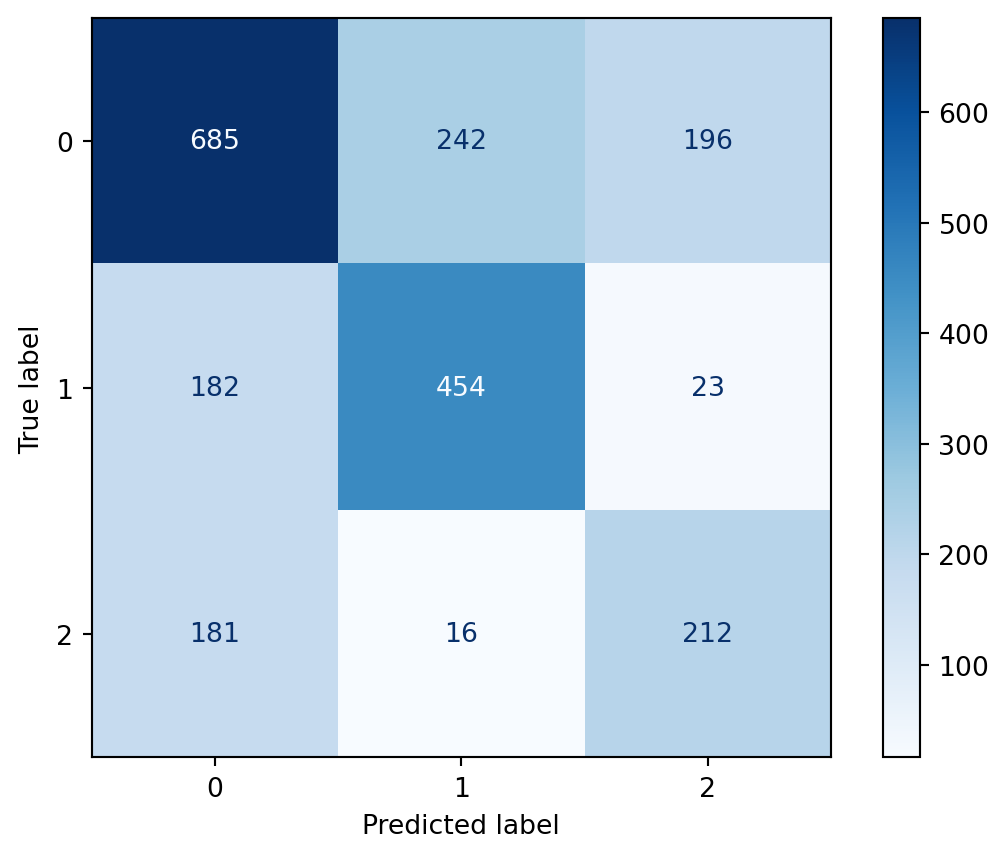

```python
y_pred_qda = cross_val_predict(qda_pipeline_best, X, y, cv=5)
cm = confusion_matrix(y, y_pred_qda)
disp = ConfusionMatrixDisplay(confusion_matrix=cm)
disp.plot(cmap="Blues")
print(cm)
```

#### 3: KNN

```python
knn_pipeline=Pipeline(
    [("preprocessing", ct_standardize),
    ("KNN", KNeighborsClassifier())]
)
knn_pipeline.fit(X,y)
```

```
Pipeline(steps=[('preprocessing',
                 ColumnTransformer(remainder='passthrough',
                                   transformers=[('standardize',
                                                  StandardScaler(),
                                                  <sklearn.compose._column_transformer.make_column_selector object at 0x14bbdf230>)])),
                ('KNN', KNeighborsClassifier())])
```

```python
knn_value = {'KNN__n_neighbors': (0.001, 0.01, 0.1, 1, 10)}

gscvknn = GridSearchCV(knn_pipeline, knn_value, cv = 5, scoring='accuracy')
gscvknn_fitted = gscvknn.fit(X, y)
print(gscvknn_fitted.best_score_, gscvknn_fitted.best_params_)
```

```
0.545432229745894 {'KNN__n_neighbors': 10}
```

Using accuracy the chosen metric, the optimal n_neighbors value for the KNN model is 10. With this value we get a cross validated accuracy score of 0.5454. We will now fit this best model on the entire dataset:

```python
knn_pipeline_best=Pipeline(
    [("preprocessing", ct_standardize),
    ("KNN", KNeighborsClassifier(n_neighbors=10))]
)
knn_pipeline_best.fit(X,y)
```

```
Pipeline(steps=[('preprocessing',
                 ColumnTransformer(remainder='passthrough',
                                   transformers=[('standardize',
                                                  StandardScaler(),
                                                  <sklearn.compose._column_transformer.make_column_selector object at 0x14bbdf230>)])),
                ('KNN', KNeighborsClassifier(n_neighbors=10))])
```

```
[[819 214  90]
 [349 297  13]
 [298  32  79]]
```

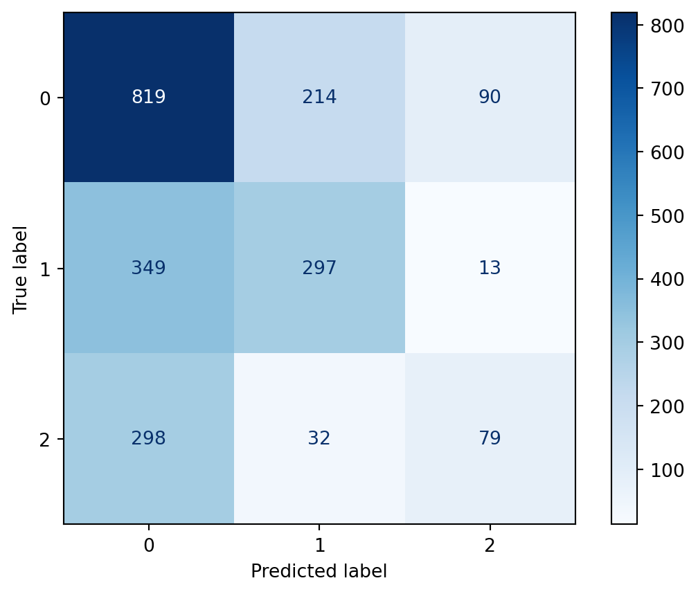

```python
y_pred_knn = cross_val_predict(knn_pipeline_best, X, y, cv=5)
cm = confusion_matrix(y, y_pred_knn)
disp = ConfusionMatrixDisplay(confusion_matrix=cm)
disp.plot(cmap="Blues")
print(cm)
```

#### 4: Metric Comparison

For confusion matrix interpretation:

```python
print(cannabis['Type'].astype('category').cat.categories)
```

```
Index(['hybrid', 'indica', 'sativa'], dtype='object')
```

0- hybrid 1- indica 2- sativa

```python
print(cannabis_type['Type'].astype('category').cat.categories)
```

```
Index(['indica', 'sativa'], dtype='object')
```

0- indica 1- sativa

Overall, our metrics were better in part 1. However, this makes sense in context due to how adding a third category to the classification options would make prediction harder generally. Also, in this dataset specifically, we can see that there are many hybrid observations and thus the models created to additionally predict the hybrid strains are swayed to ensure that those are predicted correctly (meaning more sativa/indica predictions may have gotten confused).

According to the confusion matrices, the hybrid category was predicted pretty frequently, so sativa and indica strains were commonly mistaken for hybrid strains. We can see this in the left column in the confusion matrices. This is also present in the opposite direction, where hybrid strains were estimated to be either sativa or indica. Between these two categories, hybrid strains were more commonly mistaken for indica strains.

These confusion matrices make sense in context due to the nature of our data, and how there are more hybrid observations than the other two categories. Additionally, hybrid strains are a blend of hybrid and sativa types, so it would make sense that those types would be harder to distinguish/mistaken for either one.

## Part 3: Multiclass From Binary

### Q1:

Data preparation:

```python
cannabis_ovr=cannabis
cannabis_ovr['is_indica']=((cannabis['Type']=="indica"))
cannabis_ovr['is_sativa']=((cannabis['Type']=="sativa"))
cannabis_ovr['is_hybrid']=((cannabis['Type']=="hybrid"))
```

```python
y_sativa=cannabis_ovr['is_sativa']
y_indica=cannabis_ovr['is_indica']
y_hybrid=cannabis_ovr['is_hybrid']
X_ovr=cannabis_ovr.drop(columns=['is_sativa','is_hybrid', 'is_indica', 'Type', 'Strain', 'Effects', 'Flavor'])
```

#### SVC Models:

```python
svc_pipeline.fit(X_ovr, y_sativa)
svc_pipeline.fit(X_ovr, y_indica)
svc_pipeline.fit(X_ovr, y_hybrid)
```

```
Pipeline(steps=[('preprocessing',
                 ColumnTransformer(remainder='passthrough',
                                   transformers=[('standardize',
                                                  StandardScaler(),
                                                  <sklearn.compose._column_transformer.make_column_selector object at 0x14bbdf230>)])),
                ('SVC', SVC(kernel='linear'))])
```

```python
scores_svc_sativa = cross_val_score(svc_pipeline, X_ovr, y_sativa, cv=5, scoring='accuracy')
print(scores_svc_sativa.mean())

scores_svc_indica = cross_val_score(svc_pipeline, X_ovr, y_indica, cv=5, scoring='accuracy')
print(scores_svc_indica.mean())

scores_svc_hybrid = cross_val_score(svc_pipeline, X_ovr, y_hybrid, cv=5, scoring='accuracy')
print(scores_svc_hybrid.mean())
```

```
0.8215443983316171
0.7891461499256301
0.6198032057082827
```

#### Logistic Regression Models:

```python
logistic_pipeline=Pipeline([
    ("preprocessing", ct_standardize),
    ("logistic regression", LogisticRegression())
])

logistic_pipeline.fit(X_ovr, y_hybrid)
logistic_pipeline.fit(X_ovr, y_indica)
logistic_pipeline.fit(X_ovr, y_sativa)
```

```
Pipeline(steps=[('preprocessing',
                 ColumnTransformer(remainder='passthrough',
                                   transformers=[('standardize',
                                                  StandardScaler(),
                                                  <sklearn.compose._column_transformer.make_column_selector object at 0x14bbdf230>)])),
                ('logistic regression', LogisticRegression())])
```

```python
scores_logistic_sativa = cross_val_score(logistic_pipeline, X_ovr, y_sativa, cv=5, scoring='accuracy')
print(scores_logistic_sativa.mean())

scores_logistic_indica = cross_val_score(logistic_pipeline, X_ovr, y_indica, cv=5, scoring='accuracy')
print(scores_logistic_indica.mean())

scores_logistic_hybrid = cross_val_score(logistic_pipeline, X_ovr, y_hybrid, cv=5, scoring='accuracy')
print(scores_logistic_hybrid.mean())
```

```
0.8229142613453156
0.7868640850417615
0.6156967370840745
```

```python
cannabis=cannabis.drop(columns=['is_sativa','is_hybrid', 'is_indica'])
```

### Q3:

Data preparation:

```python
is_indica_or_sativa=(cannabis["Type"]=="indica")|(cannabis["Type"]=="sativa")
is_indica_or_hybrid=(cannabis["Type"]=="indica")|(cannabis["Type"]=="hybrid")
is_hybrid_or_sativa=(cannabis["Type"]=="hybrid")|(cannabis["Type"]=="sativa")

cannabis_1=cannabis[is_indica_or_sativa]
cannabis_2=cannabis[is_indica_or_hybrid]
cannabis_3=cannabis[is_hybrid_or_sativa]
```

```python
X_1=cannabis_1.drop(columns=['Type', 'Strain', 'Effects', 'Flavor'])
y_1=cannabis_1['Type']

X_2=cannabis_2.drop(columns=['Type', 'Strain', 'Effects', 'Flavor'])
y_2=cannabis_2['Type']

X_3=cannabis_3.drop(columns=['Type', 'Strain', 'Effects', 'Flavor'])
y_3=cannabis_3['Type']
```

#### SVC Models:

```python
svc_pipeline.fit(X_1, y_1)
svc_pipeline.fit(X_2, y_2)
svc_pipeline.fit(X_3, y_3)
```

```
Pipeline(steps=[('preprocessing',
                 ColumnTransformer(remainder='passthrough',
                                   transformers=[('standardize',
                                                  StandardScaler(),
                                                  <sklearn.compose._column_transformer.make_column_selector object at 0x14bbdf230>)])),
                ('SVC', SVC(kernel='linear'))])
```

```python
scores_svc_1 = cross_val_score(svc_pipeline, X_1, y_1, cv=5, scoring='accuracy')
print(scores_svc_1.mean())

scores_svc_2 = cross_val_score(svc_pipeline, X_2, y_2, cv=5, scoring='accuracy')
print(scores_svc_2.mean())

scores_svc_3 = cross_val_score(svc_pipeline, X_3, y_3, cv=5, scoring='accuracy')
print(scores_svc_3.mean())
```

```
0.8576806634197711
0.7575834828313347
0.7440952928402631
```

#### Logistic Regression Models:

```python
logistic_pipeline.fit(X_1, y_1)
logistic_pipeline.fit(X_2, y_2)
logistic_pipeline.fit(X_3, y_3)
```

```
Pipeline(steps=[('preprocessing',
                 ColumnTransformer(remainder='passthrough',
                                   transformers=[('standardize',
                                                  StandardScaler(),
                                                  <sklearn.compose._column_transformer.make_column_selector object at 0x14bbdf230>)])),
                ('logistic regression', LogisticRegression())])
```

```python
scores_log_1 = cross_val_score(logistic_pipeline, X_1, y_1, cv=5, scoring='accuracy')
print(scores_log_1.mean())

scores_log_2 = cross_val_score(logistic_pipeline, X_2, y_2, cv=5, scoring='accuracy')
print(scores_log_2.mean())

scores_log_3 = cross_val_score(logistic_pipeline, X_3, y_3, cv=5, scoring='accuracy')
print(scores_log_3.mean())
```

```
0.8511298319512088
0.7457920246750386
0.7447637904238785
```

### Q5:

Logistic regression would automatically take an “OVR” approach, and SVC would automatically take a “OVO” approach.